# Clustering

Examples concerning the [`sklearn.cluster`](https://scikit-learn.org/1.6/api/sklearn.cluster.html#module-sklearn.cluster) module.

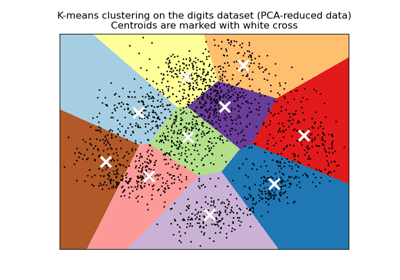

A demo of K-Means clustering on the handwritten digits data

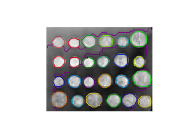

A demo of structured Ward hierarchical clustering on an image of coins

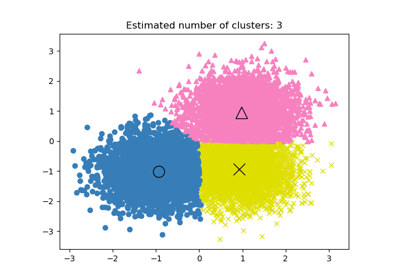

A demo of the mean-shift clustering algorithm

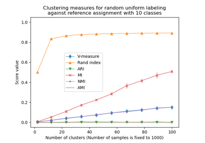

Adjustment for chance in clustering performance evaluation

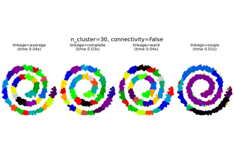

Agglomerative clustering with and without structure

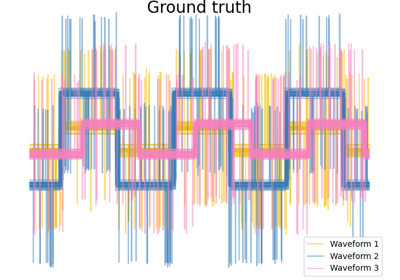

Agglomerative clustering with different metrics

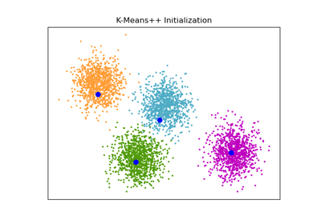

An example of K-Means++ initialization

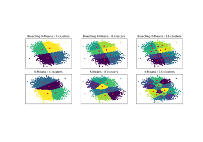

Bisecting K-Means and Regular K-Means Performance Comparison

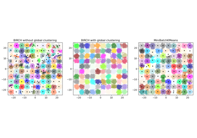

Compare BIRCH and MiniBatchKMeans

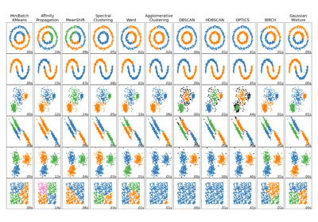

Comparing different clustering algorithms on toy datasets

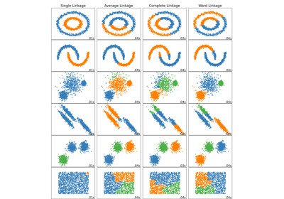

Comparing different hierarchical linkage methods on toy datasets

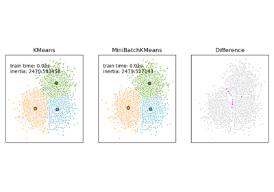

Comparison of the K-Means and MiniBatchKMeans clustering algorithms

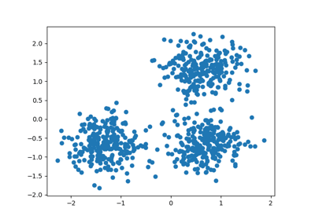

Demo of DBSCAN clustering algorithm

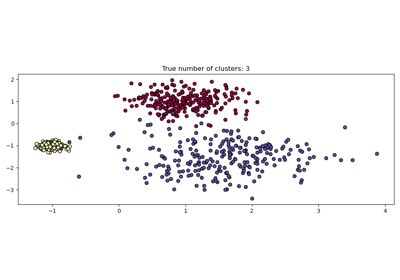

Demo of HDBSCAN clustering algorithm

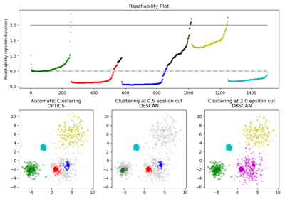

Demo of OPTICS clustering algorithm

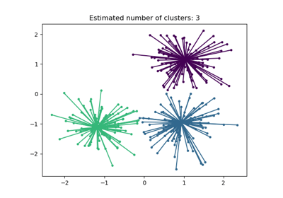

Demo of affinity propagation clustering algorithm

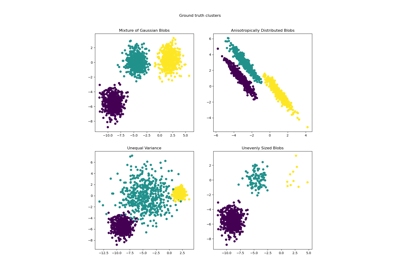

Demonstration of k-means assumptions

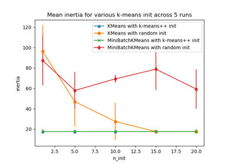

Empirical evaluation of the impact of k-means initialization

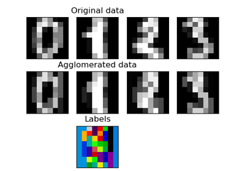

Feature agglomeration

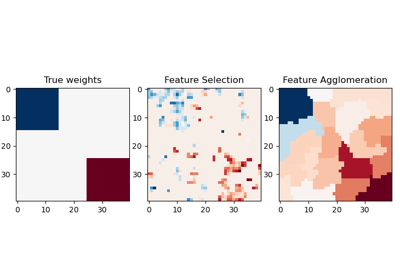

Feature agglomeration vs. univariate selection

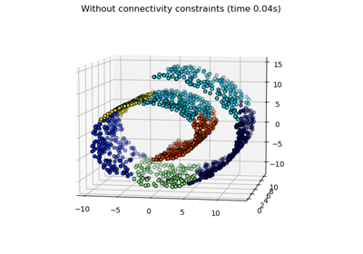

Hierarchical clustering: structured vs unstructured ward

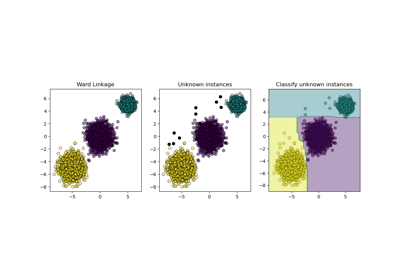

Inductive Clustering

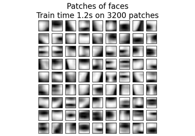

Online learning of a dictionary of parts of faces

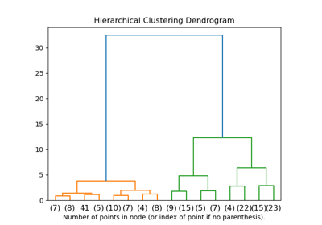

Plot Hierarchical Clustering Dendrogram

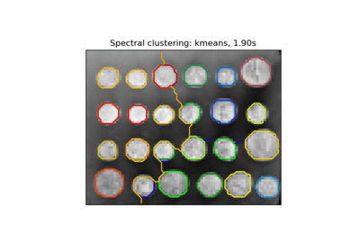

Segmenting the picture of greek coins in regions

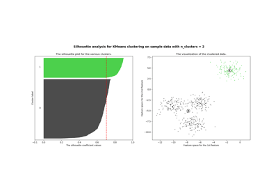

Selecting the number of clusters with silhouette analysis on KMeans clustering

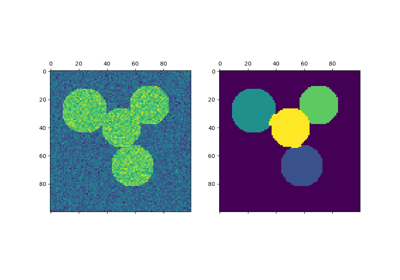

Spectral clustering for image segmentation

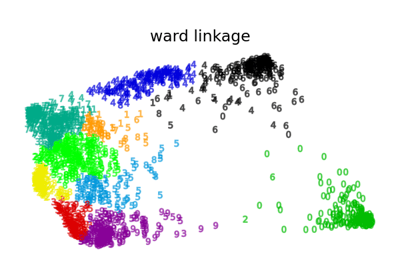

Various Agglomerative Clustering on a 2D embedding of digits

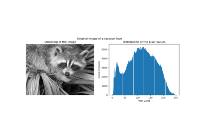

Vector Quantization Example

© 2007–2025 The scikit-learn developers  
Licensed under the 3-clause BSD License.  
https://scikit-learn.org/1.6/auto_examples/cluster/index.html